# Technology and Social Change

Logical Argumentation: Building Strong Arguments and Avoiding Common Errors

Bogdan G. Popescu

bgpopescu@tec.mx

Tecnológico de Monterrey

# Introduction

[video not shown]

## Why This Lecture?

- Tech and development debates often sound convincing
- Many rely on flawed reasoning or missing evidence

Two core skills for this class and beyond:

- **Build** clear, evidence-based arguments
- **Detect** flawed reasoning in others’ claims

## Roadmap

1. Anatomy of a good argument
2. Deductive vs. inductive reasoning
3. Eleven logical fallacies to avoid
4. Practice exercises

## So What?

### From persuasion to logic

- Sounding persuasive is not the same as being right
- Structure separates strong claims from noise

**Next →** What does a well-built argument look like?

# I. Anatomy of a Good Argument

## What Is an Argument?

### Not a fight — a structured case

An **argument** is a claim supported by evidence and reasoning

Four essential components:

- **Claim**: states your position
- **Evidence**: supports the claim with facts or data
- **Warrant**: explains *why* evidence supports the claim
- **Scope**: qualifies where and when the claim holds

## The Four Components

### How they fit together

1. CLAIM  
State your position

→

2. EVIDENCE  
Facts, data, studies

→

3. WARRANT  
Why it supports claim

→

4. SCOPE  
Where and when

## Weak Argument

### What’s wrong here?

“AI is dangerous because it will take all our jobs.”

- ✗ Vague claim — which jobs? Where?
- ✗ No evidence cited
- ✗ No mechanism explained
- ✗ No scope or limits stated

## Strong Argument

### The same topic, done right

“AI-driven automation could displace 85 million jobs globally by 2025 (World Economic Forum, 2020), primarily in routine clerical and manufacturing tasks in advanced economies.”

- ✓ Specific, testable claim
- ✓ Named source with a number
- ✓ Mechanism: routine task automation
- ✓ Scope: specific job types and regions

## Qualifying Your Claims

### Precision builds credibility

| Overconfident | Qualified |
| --- | --- |
| AI **will** destroy all jobs | AI **is likely to** displace routine tasks |
| AI **causes** discrimination | AI **can reproduce** biases in training data |
| AI regulation **always** stifles innovation | Regulation’s effect **depends on** design and enforcement |

> Strong writers qualify claims — weak writers hide behind absolutes.

## But Wait: Isn’t “AI Will Take Your Job” More Memorable?

### The tension between precision and punch

- Absolutes are **sticky**: “AI will destroy jobs” lands harder
- But sticky ≠ correct — audiences notice overstatement

**The solution**: lead sharp, then qualify immediately

- “AI is coming for routine jobs — and the data backs it up”
- Memorable *and* defensible

> The goal is not to sound boring. It’s to sound **confident and precise**.

## Try It: Rewrite for Punch + Precision

**Boring but accurate**: “Some studies suggest AI may be associated with job displacement in certain sectors under specific conditions.”

**Sharp and qualified**: ???

*Take 30 seconds — rewrite this so it’s both memorable and defensible.*

**One version**: “AI is already replacing call center workers and data entry clerks — and the trend is accelerating in economies that can’t retrain fast enough.”

# II. Common Argument Structures

## Deductive Reasoning

### Start with a rule, apply it to a case

**General rule**: automation of routine tasks displaces workers

**Specific case**: AI automates clerical and manufacturing tasks

**∴ Conclusion**: AI will displace workers in those roles

- **Why it’s powerful**: if the rule holds, the conclusion *must* follow
- **The catch**: the rule itself might be wrong or incomplete

## Inductive Reasoning

### Specific observations → general conclusion

Patterns *suggest* but don’t guarantee a conclusion:

1. AI hiring tools showed gender bias at Amazon (2018)
2. Facial recognition misidentified darker-skinned faces more often (Buolamwini & Gebru, 2018)
3. Predictive policing amplified racial disparities in the U.S.
4. ∴ AI systems *tend to* reproduce biases in training data
- **Strength**: grounded in observed evidence
- **Risk**: new cases could disprove the pattern

## Two Directions of Reasoning

DEDUCTIVE

General Rule

→

Specific Case

→

Certain Conclusion

INDUCTIVE

Observations

→

Find Pattern

→

Probable Conclusion

Most academic arguments use **both**: induction to find patterns, deduction to apply them.

## Deductive vs. Inductive

### When to use each

|  | Deductive | Inductive |
| --- | --- | --- |
| **Direction** | General → Specific | Specific → General |
| **Certainty** | Certain (if premises true) | Probable |
| **Best for** | Applying theories | Building from evidence |
| **Watch for** | False premises | Hasty generalization |

Both are powerful — but both can go wrong in predictable ways. **Next**: eleven common errors.

# III. Logical Fallacies

## What Is a Fallacy?

- Errors in reasoning that *appear* persuasive
- Used intentionally or accidentally to mislead

**Two goals for this section**:

- Recognize fallacies in others’ arguments
- Avoid them in your own

## Fallacy Families

### Three categories of errors

| Evidence Errors | Reasoning Errors | Rhetorical Tricks |
| --- | --- | --- |
| Cherry Picking | False Dilemma | Ad Hominem |
| Hasty Generalization | Strawman | Appeal to Authority |
| Correlation ≠ Causation | Slippery Slope | Appeal to Emotion |
| Ecological Fallacy | Sunk Cost |  |

# Rhetorical Tricks

## Ad Hominem

### Rhetorical Trick

- Attacks the person, not the argument
- Shifts focus from evidence to character
- Watch for: insults, motive questioning, associations

**Examples**

- “She’s not a scientist — ignore her climate views”
- “He’s a billionaire — of course he defends AI”

## What’s Wrong With This?

> “Elon Musk says AI is humanity’s biggest threat. He’s a genius — that settles it.”

**The fallacy**: Appeal to Authority

- Uses a famous person’s opinion as evidence
- Musk is an engineer, not an AI safety researcher
- Reputation ≠ expertise on the specific topic

## Appeal to Emotion

### Rhetorical Trick

> “Picture a five-year-old asking: ‘Mommy, will a robot take your job?’ That’s the future if we don’t act NOW.”
- Manipulates fear or pity instead of presenting evidence
- The image is vivid — but what’s the actual data?
- Watch for: dramatic stories, loaded language, urgency without facts

# Evidence Errors

## Cherry Picking

### Evidence Error

- Selects evidence that supports a claim
- Ignores data that contradicts it
- Watch for: one-sided statistics, single studies cited

**Examples**

- “China’s GDP growth proves authoritarianism drives development”
- “This one study shows no climate impact”

## Hasty Generalization

### Evidence Error

- Draws conclusions from insufficient evidence
- Overgeneralizes from one case or small samples
- Watch for: anecdotes treated as universal proof

**Examples**

- “My cousin’s factory closed — free trade destroys jobs”
- “One village doesn’t use solar — renewables fail in Africa”

## Ecological Fallacy

### Evidence Error

- Infers individual traits from group-level data
- Group averages don’t apply to every member
- Watch for: national statistics applied to individuals

**Examples**

- “India’s tech sector booms, so all Indians benefit”
- “Average income is high, so all residents are wealthy”

## Correlation ≠ Causation

### Evidence Error

- Assumes co-occurrence proves a causal link
- Ignores confounders and reversed causality
- Watch for: “X increases with Y, therefore X causes Y”

**Examples**

- “More internet users → higher GDP, so internet causes growth”
- “Laptop users get worse grades — ban laptops!”

## How Confounders Mislead

### The hidden variable problem

Wealth & Institutions

↙ ↘

Internet Access

GDP Growth

- - - "looks causal" - - - →

The confounder (wealth) drives **both** variables, creating a spurious correlation.

## Seeing Correlation in Action

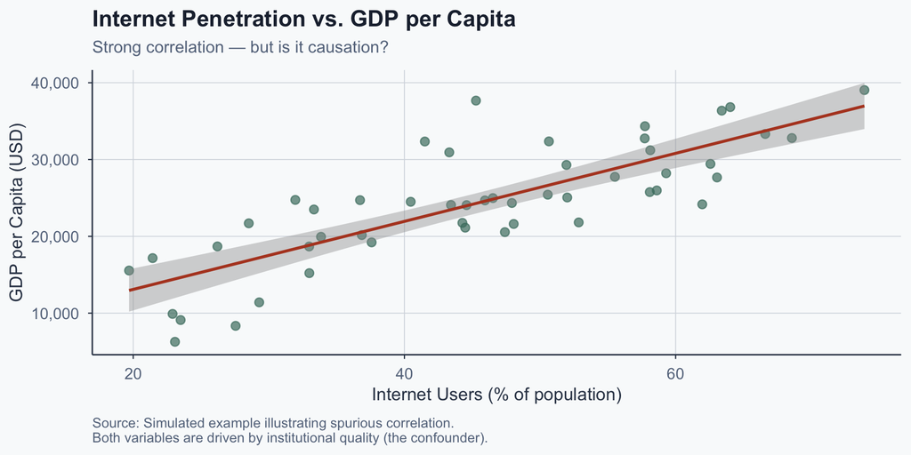

Figure 1: Correlation driven by a hidden confounder.

# Reasoning Errors

## What’s Wrong With This?

> “Either we ban AI entirely, or we accept mass unemployment. There’s no middle ground.”

**The fallacy**: False Dilemma

- Presents only two options when more exist
- What about regulation, retraining, UBI, gradual adoption?
- Watch for: “either… or” framing that hides alternatives

## Strawman

### Reasoning Error — A real debate example

**What was actually said**:

“We should require AI companies to disclose their training data sources.”

**The strawman version**:

“They want to shut down AI research and hand control of technology to bureaucrats!”

- Distorts the original to make it easier to attack
- Watch for: extreme restatements, words never said

## Slippery Slope

### Reasoning Error

- Assumes one action leads to extreme outcomes
- No evidence for the claimed causal chain
- Watch for: “if we allow X, then Y, then Z…”

**Examples**

- “Regulate AI today → stifle all innovation permanently”
- “Allow gene editing for disease → designer babies next”

## Sunk Cost Fallacy

### Reasoning Error

- Past investments drive decisions, not future benefits
- Justifies continuing a failing endeavor
- Watch for: “we’ve already spent too much to stop”

**Examples**

- “We spent $2B on this dam — we can’t stop now”
- “Three years in this startup — I must keep going”

## In Practice, Fallacies Overlap

### Real arguments are messier than a taxonomy

> “Africa received billions in aid and is still poor. Aid is a failure.”
- **Hasty Generalization**: one continent, dozens of different outcomes
- **Cherry Picking**: ignores countries where aid worked
- **Ecological Fallacy**: “Africa” is not a single case

When diagnosing an argument, don’t stop at the first fallacy you spot — **look for layers**.

# IV. Practice

## Exercise 1: Spot the Fallacy

### Identify the error in each statement

1. “Bill Gates says nuclear solves climate change. Case closed.”

→ **Appeal to Authority** — rests on reputation, not evidence

2. “Africa got billions in aid and is still poor. Aid fails.”

→ **Hasty Generalization** — ignores variation across countries

3. “Let tech companies self-regulate → they’ll control governments.”

→ **Slippery Slope** — no evidence for the causal chain

## Exercise 2: Fix the Argument

### Rewrite to make it credible and qualified

**Weak**: “Social media is destroying democracy.”

**Possible fix**: “Allcott & Gentzkow (2017) found fake news on Facebook increased polarization in the 2016 U.S. election. Algorithmic amplification can undermine informed participation, especially where media literacy is low.”

## Exercise 2 (continued)

**Weak**: “The Green Revolution proved technology solves hunger.”

**What’s wrong**: treats one case as universal proof (hasty generalization), ignores environmental costs and unequal access (cherry picking), removes all scope.

**Possible fix**: “The Green Revolution increased cereal yields 2–3x in South and Southeast Asia between 1965–1985 (Evenson & Gollin, 2003), but gains were concentrated among farmers who could afford inputs, and environmental costs were significant.”

## Exercise 3: Build an Argument

### Choose one claim (5 minutes to write)

Pick one:

1. “AI will widen inequality between rich and poor countries”
2. “Universal basic income beats retraining for automation”
3. “Open-source tech accelerates development more than proprietary”

## Exercise 3: Template

### Fill in each box

| Component | Your argument |
| --- | --- |
| **Claim** | ___ (your position in one sentence) |
| **Evidence** | ___ (one fact, study, or case) |
| **Warrant** | ___ (why this evidence supports the claim) |
| **Scope** | ___ (where does it hold? what are the limits?) |

## Exercise 4: Debate Swap

### Test your argument against a partner (10 minutes)

**3 min** — read your partner’s argument silently and note:

- Any fallacies in their reasoning?
- Missing evidence or unwarranted leaps?
- Where could the scope be tighter?

**4 min** — exchange feedback (2 min each)

**3 min** — revise your argument, then one pair presents

## So What?

### From exercises to everyday thinking

- These are not just classroom skills
- Every policy debate, news article, and pitch uses arguments

**Your challenge →** spot one fallacy in the wild this week

# Conclusion

## Key Takeaways

1. Strong arguments have **claim, evidence, warrant, and scope**
2. **Deductive** applies principles; **inductive** builds from evidence
3. **Qualifying** claims makes them stronger, not weaker
4. Fallacies are **reasoning errors**, not necessarily lies
5. They cluster into evidence, reasoning, and rhetorical errors
6. The best way to improve: **build, break, rebuild**